# Chap5

## 第五章 绘图模块

本章主要介绍Python中的绘图模块：Matplotlib的使用。人类受限于思维能力理解数据的方法及其有限，一部分是通过数字特征一部分是结合商业业务知识。那么把这两者完美的结合起来的方式就是通过探索性数据分析,这也是数据学科中针对商业数据分析最重要的一步。探索性数据分析其实是试图通过数字特征与数据可视化的方式结合业务知识展示数据。在Python中这个功能将会通过Matplotlib模块来实现。

## 第一节 基本绘图

- 线图
- 散点图
- legend

```python
import matplotlib.pyplot as plt ## 画图必备
import numpy as np
import pandas as pd
```

第一幅图

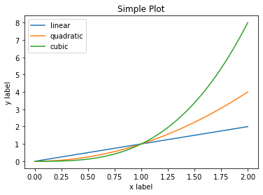

```python
x = np.linspace(0, 2, 100)

plt.plot(x, x, label='linear')
plt.plot(x, x**2, label='quadratic')
plt.plot(x, x**3, label='cubic')

plt.xlabel('x label')
plt.ylabel('y label')

plt.title("Simple Plot")

plt.legend()

plt.show()
```

画什么样的图？点图还是线图？什么样的点？什么样的线？怎样控制这些参数？

简单作图法

```python
fig = plt.figure()  # an empty figure with no axes
fig.suptitle('No axes on this figure')  # Add a title so we know which it is
plt.show()
```

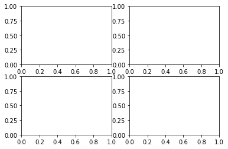

```python
fig, ax_lst = plt.subplots(2, 2)  # a figure with a 2x2 grid of Axes
```

再看一种code风格

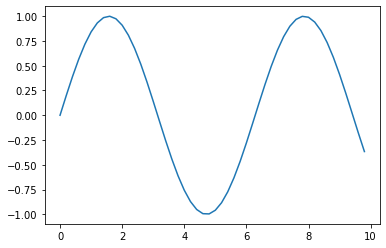

```python
x = np.arange(0, 10, 0.2)
y = np.sin(x)
fig, ax = plt.subplots()
ax.plot(x, y)
plt.show()
```

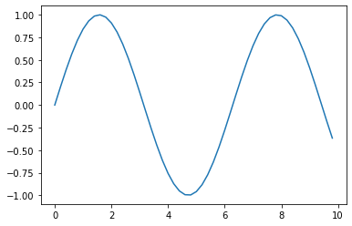

```python
x = np.arange(0, 10, 0.2)
y = np.sin(x)
plt.plot(x, y)
plt.show()
```

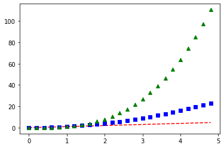

```python
t = np.arange(0., 5., 0.2)

# red dashes, blue squares and green triangles
plt.plot(t, t, 'r--', t, t**2, 'bs', t, t**3, 'g^')
plt.show()
```

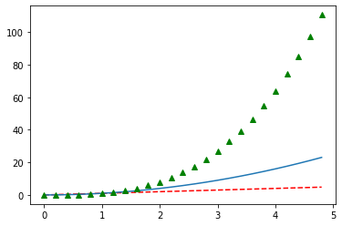

```python
t = np.arange(0., 5., 0.2)

# red dashes, blue squares and green triangles
plt.plot(t, t, 'r--', t, t**2, t, t**3, 'g^') ## 默认是'b-':blue line
plt.show()
```

图中点线的更多特征

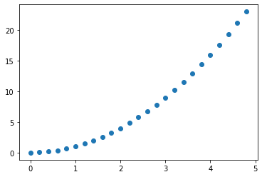

```python
plt.scatter(t,t**2)
```

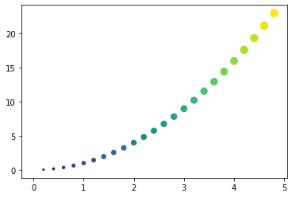

```python
plt.scatter(t,t**2,c=t,s=t*20)
```

```python
X = pd.read_csv('./sk600848.csv')
```

```python
X.head()
```

|  | date | open | high | close | low | volume | price_change | p_change | ma5 | ma10 | ma20 | v_ma5 | v_ma10 | v_ma20 |
| --- | --- | --- | --- | --- | --- | --- | --- | --- | --- | --- | --- | --- | --- | --- |
| 0 | 2019-09-24 | 27.67 | 27.80 | 27.33 | 27.31 | 66308.66 | -0.31 | -1.12 | 27.764 | 27.667 | 27.512 | 89855.82 | 88897.67 | 102737.68 |
| 1 | 2019-09-23 | 28.00 | 28.19 | 27.64 | 27.50 | 76006.28 | -0.65 | -2.30 | 27.814 | 27.712 | 27.489 | 98391.88 | 92873.16 | 105143.73 |
| 2 | 2019-09-20 | 27.96 | 28.88 | 28.29 | 27.67 | 125565.73 | 0.49 | 1.76 | 27.820 | 27.680 | 27.496 | 100271.05 | 93751.82 | 109555.71 |
| 3 | 2019-09-19 | 27.83 | 28.02 | 27.80 | 27.47 | 77383.31 | 0.04 | 0.14 | 27.672 | 27.593 | 27.493 | 94281.90 | 96297.90 | 113326.60 |
| 4 | 2019-09-18 | 27.57 | 28.14 | 27.76 | 27.54 | 104015.14 | 0.18 | 0.65 | 27.594 | 27.518 | 27.566 | 92297.68 | 96419.84 | 125383.74 |

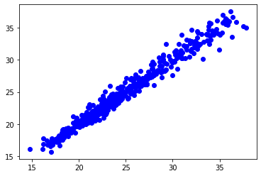

```python
plt.plot('open','close','bo',data = X)
```

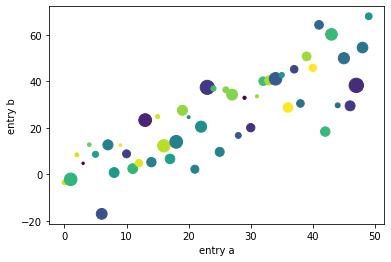

```python
data = {'a': np.arange(50),
        'c': np.random.randint(0, 50, 50),
        'd': np.random.randn(50)}
data['b'] = data['a'] + 10 * np.random.randn(50)
data['d'] = np.abs(data['d']) * 100

plt.scatter('a', 'b', c='c', s='d', data=data)
plt.xlabel('entry a')
plt.ylabel('entry b')
plt.show()
```

X 轴可以是分类变量

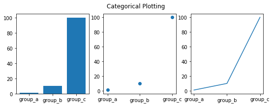

```python
names = ['group_a', 'group_b', 'group_c']
values = [1, 10, 100]

plt.figure(figsize=[9,3]) ## 注意这个参数

plt.subplot(131)
plt.bar(names, values)
plt.subplot(132)
plt.scatter(names, values)
plt.subplot(133)
plt.plot(names, values)
plt.suptitle('Categorical Plotting')
plt.show()
```

plot 调用的一般格式：

plot([x], y, [fmt], *, data=None,* * kwargs)

plot([x], y, [fmt], [x2], y2, [fmt2], ..., kwargs)

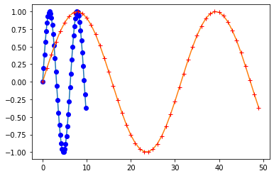

```python
plt.plot(x, y)        # plot x and y using default line style and color
plt.plot(x, y, 'bo')  # plot x and y using blue circle markers
plt.plot(y)           # plot y using x as index array 0..N-1
plt.plot(y, 'r+')     # with red plusses
```

```python
x=np.linspace(0,1,20)
```

```python
y = x**2
```

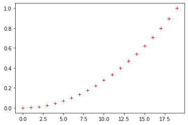

```python
plt.plot(y,'r+')
```

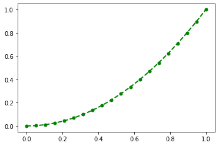

```python
plt.plot(x, y, 'go--', linewidth=2, markersize=5)
```

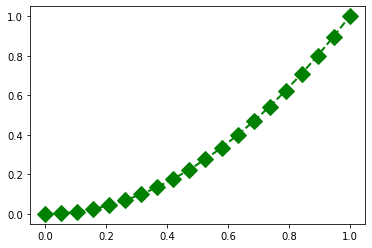

```python
plt.plot(x, y, color='green', marker='D', linestyle='dashed',
     linewidth=2, markersize=12)
```

```python
?plt.plot
```

画多个图形

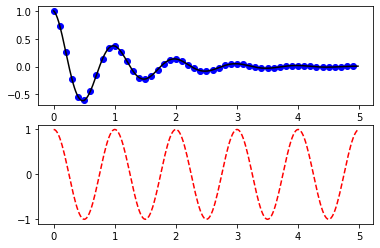

```python
def f(t):
    return np.exp(-t) * np.cos(2*np.pi*t)

t1 = np.arange(0.0, 5.0, 0.1)
t2 = np.arange(0.0, 5.0, 0.02)

plt.figure()
plt.subplot(211)
plt.plot(t1, f(t1), 'bo', t2, f(t2), 'k')

plt.subplot(212)
plt.plot(t2, np.cos(2*np.pi*t2), 'r--')
```

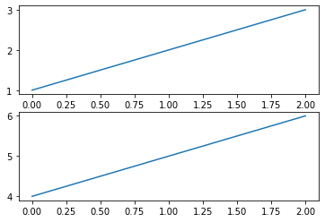

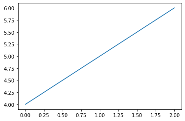

```python
import matplotlib.pyplot as plt
plt.figure(1)                # the first figure
plt.subplot(211)             # the first subplot in the first figure
plt.plot([1, 2, 3])
plt.subplot(212)             # the second subplot in the first figure
plt.plot([4, 5, 6])


plt.figure(2)                # a second figure
plt.plot([4, 5, 6])          # creates a subplot(111) by default
```

在图片上添加文本

- plt.xlabel
- plt.ylabel
- plt.title
- plt.text

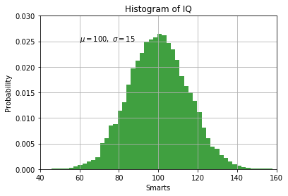

```python
mu, sigma = 100, 15
x = mu + sigma * np.random.randn(10000)

# the histogram of the data
n, bins, patches = plt.hist(x, 50, density=1, facecolor='g', alpha=0.75)


plt.xlabel('Smarts')  ## 在x轴添加文本
plt.ylabel('Probability')  ## 在y轴添加文本
plt.title('Histogram of IQ') ## 添加标题
plt.text(60, .025, r'$\mu=100,\ \sigma=15$') ## 在（60，0.025）坐标处添加文本, 同时注意公式的使用 r是必须的
plt.axis([40, 160, 0, 0.03])
plt.grid(True)
plt.show()
```

## 第二节 绘图进阶

- 画图的全过程
- 从数据开始
- 开始画图
- 中间修改
- 最后存储

Data： 一些公司的销售额

```python
# sphinx_gallery_thumbnail_number = 10
import numpy as np
import matplotlib.pyplot as plt
from matplotlib.ticker import FuncFormatter

data = {'Barton LLC': 109438.50,
        'Frami, Hills and Schmidt': 103569.59,
        'Fritsch, Russel and Anderson': 112214.71,
        'Jerde-Hilpert': 112591.43,
        'Keeling LLC': 100934.30,
        'Koepp Ltd': 103660.54,
        'Kulas Inc': 137351.96,
        'Trantow-Barrows': 123381.38,
        'White-Trantow': 135841.99,
        'Will LLC': 104437.60}
group_data = list(data.values())
group_names = list(data.keys())
group_mean = np.mean(group_data)
```

```python
group_data
```

```
[109438.5,
 103569.59,
 112214.71,
 112591.43,
 100934.3,
 103660.54,
 137351.96,
 123381.38,
 135841.99,
 104437.6]
```

```python
group_names
```

```
['Barton LLC',
 'Frami, Hills and Schmidt',
 'Fritsch, Russel and Anderson',
 'Jerde-Hilpert',
 'Keeling LLC',
 'Koepp Ltd',
 'Kulas Inc',
 'Trantow-Barrows',
 'White-Trantow',
 'Will LLC']
```

```python
group_mean
```

```
114342.2
```

1. 产生一个画图的对象，（fig，ax）

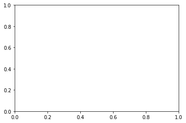

```python
fig, ax = plt.subplots()
```

```python
ax.barh(group_names, group_data)
```

```
<BarContainer object of 10 artists>
```

```python
plt.style.use('fivethirtyeight')
```

[output not shown]

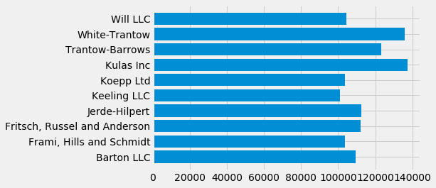

```python
fig, ax = plt.subplots()
ax.barh(group_names, group_data)
```

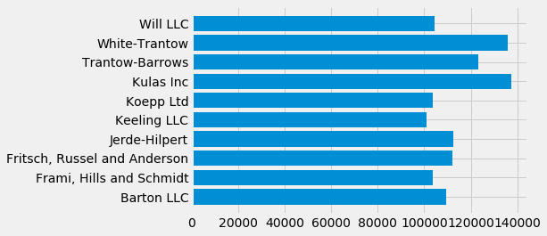

```python
fig, ax = plt.subplots()
ax.barh(group_names, group_data)
labels = ax.get_xticklabels()
```

[output not shown]

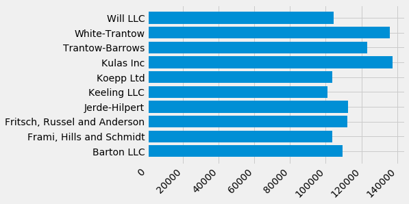

```python
fig, ax = plt.subplots()
ax.barh(group_names, group_data)
labels = ax.get_xticklabels()
plt.setp(labels, rotation=45, horizontalalignment='right')
```

```
[None,
 None,
 None,
 None,
 None,
 None,
 None,
 None,
 None,
 None,
 None,
 None,
 None,
 None,
 None,
 None,
 None,
 None]
```

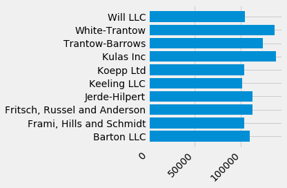

```python
plt.rcParams.update({'figure.autolayout': True})

fig, ax = plt.subplots()
ax.barh(group_names, group_data)
labels = ax.get_xticklabels()
plt.setp(labels, rotation=45, horizontalalignment='right')
```

[output not shown]

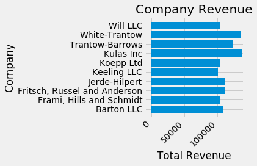

```python
fig, ax = plt.subplots()
ax.barh(group_names, group_data)
labels = ax.get_xticklabels()
plt.setp(labels, rotation=45, horizontalalignment='right')
ax.set(xlim=[-10000, 140000], xlabel='Total Revenue', ylabel='Company',
       title='Company Revenue')
```

[output not shown]

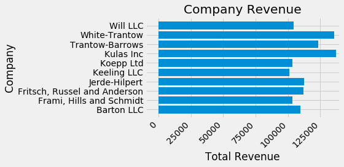

```python
fig, ax = plt.subplots(figsize=(8, 4))
ax.barh(group_names, group_data)
labels = ax.get_xticklabels()
plt.setp(labels, rotation=45, horizontalalignment='right')
ax.set(xlim=[-10000, 140000], xlabel='Total Revenue', ylabel='Company',
       title='Company Revenue')
```

```python
def currency(x, pos):
    """The two args are the value and tick position"""
    if x >= 1e6:
        s = '${:1.1f}M'.format(x*1e-6)
    else:
        s = '${:1.0f}K'.format(x*1e-3)
    return s

formatter = FuncFormatter(currency)
```

```python
currency(30000,1)
```

```
'$30K'
```

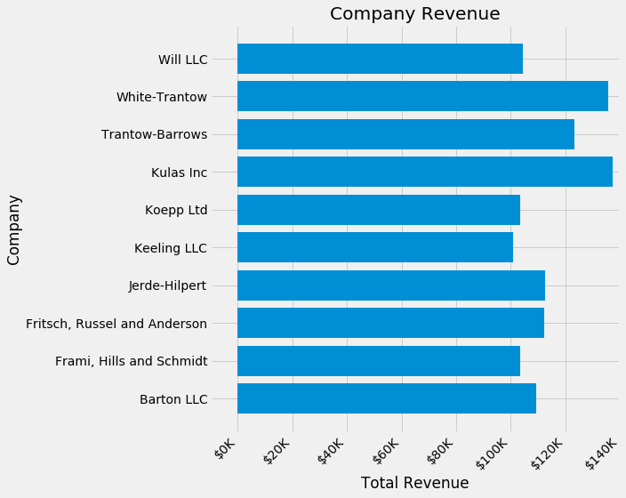

```python
fig, ax = plt.subplots(figsize=(10, 8))
ax.barh(group_names, group_data)
labels = ax.get_xticklabels()
plt.setp(labels, rotation=45, horizontalalignment='right')

ax.set(xlim=[-10000, 140000], xlabel='Total Revenue', ylabel='Company',
       title='Company Revenue')
ax.xaxis.set_major_formatter(formatter)
```

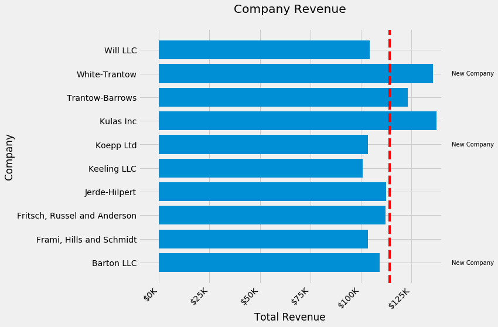

```python
fig, ax = plt.subplots(figsize=(12, 8))
ax.barh(group_names, group_data)
labels = ax.get_xticklabels()
plt.setp(labels, rotation=45, horizontalalignment='right')

# Add a vertical line, here we set the style in the function call
ax.axvline(group_mean, ls='--', color='r')

# Annotate new companies
for group in [0, 5, 8]:
    ax.text(145000, group, "New Company", fontsize=10,
            verticalalignment="center")

# Now we'll move our title up since it's getting a little cramped
ax.title.set(y=1.05)

ax.set(xlim=[-10000, 140000], xlabel='Total Revenue', ylabel='Company',
       title='Company Revenue')
ax.xaxis.set_major_formatter(formatter)
ax.set_xticks([0, 25e3, 50e3, 75e3, 100e3, 125e3])
fig.subplots_adjust(right=.1)

plt.show()
```

```python
print(fig.canvas.get_supported_filetypes())
```

```
{'ps': 'Postscript', 'eps': 'Encapsulated Postscript', 'pdf': 'Portable Document Format', 'pgf': 'PGF code for LaTeX', 'png': 'Portable Network Graphics', 'raw': 'Raw RGBA bitmap', 'rgba': 'Raw RGBA bitmap', 'svg': 'Scalable Vector Graphics', 'svgz': 'Scalable Vector Graphics', 'jpg': 'Joint Photogr…
```

```python
fig.savefig('sales.png', transparent=False, dpi=80, bbox_inches="tight")
```

```python
fig.savefig('sales.pdf', transparent=False, dpi=80, bbox_inches="tight")
```

```python
from matplotlib.backends.backend_pdf import PdfPages
with PdfPages('twopages.pdf') as pdf:
    plt.plot([1,2,3,4,5])
    pdf.savefig()
    plt.close()

    plt.plot([3,4,5,6,7])
    pdf.savefig()
    plt.close()
```